# Modeling temperatures and sales

## Modeling temperatures and sales

Let's look at two temperature readings from Brussels, Belgium in our first example. We'll later model sales data using a very basic approach.

```python
import matplotlib.pyplot as plt
import pylab as plt_lab

import numpy as np
import pandas as pd
import os, matplotlib
import seaborn as sns
from datetime import datetime, date, time, timedelta

import warnings
warnings.filterwarnings('ignore')
%matplotlib inline
```

```python
def search_import_file(a,b):
    liste=[]
    for i in os.listdir(os.path.curdir):
        liste.append(i)
    for file in liste:
        if (file.startswith(a) and file.endswith(b)):
            curdir = os.path.abspath(os.path.curdir)
            path_to_file = os.path.join(curdir,file)
            # print("found",path_to_file)
    return path_to_file

df = pd.read_excel(search_import_file('data','xlsx'), sheetname='Temperature', index_col='Hour')
```

```python
df[(df.Month==7) & (df.Day==5)][['Temperature']]

# which is equivalent to

df.query('Month==7 & Day==5')[['Temperature']]
```

| Hour | Temperature |
| --- | --- |
| 0 | 19.62 |
| 1 | 18.76 |
| 2 | 17.62 |
| 3 | 16.71 |
| 4 | 15.98 |
| 5 | 15.50 |
| 6 | 15.03 |
| 7 | 15.93 |
| 8 | 17.54 |
| 9 | 19.83 |
| 10 | 21.73 |
| 11 | 23.13 |
| 12 | 24.49 |
| 13 | 25.68 |
| 14 | 26.54 |
| 15 | 26.81 |
| 16 | 26.83 |
| 17 | 26.62 |
| 18 | 26.12 |
| 19 | 25.35 |
| 20 | 24.27 |
| 21 | 22.85 |
| 22 | 21.04 |
| 23 | 19.41 |

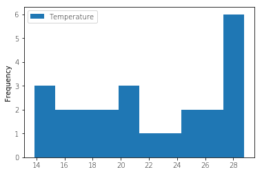

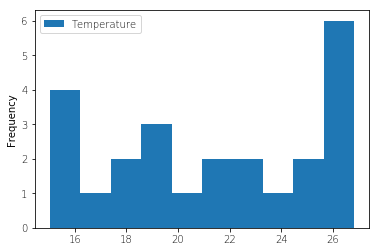

```python
df_June = df[(df.Month==6) & (df.Day==29)][['Temperature']]
df_July = df[(df.Month==7) & (df.Day==5)][['Temperature']]

df_June.plot.hist();
df_July.plot.hist();
```

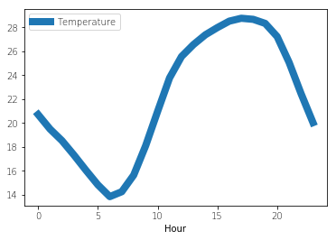

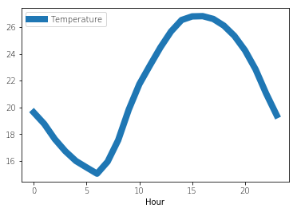

```python
df_June.plot();
df_July.plot();
```

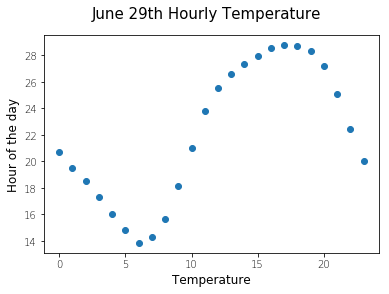

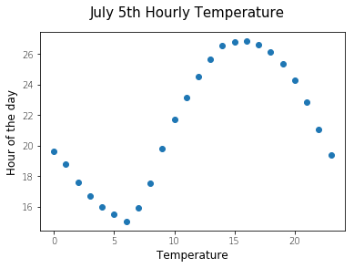

```python
fig = plt.figure()

fig.suptitle('June 29th Hourly Temperature', fontsize=15)#, fontweight='bold')

ax = fig.add_subplot(111)
ax.set_xlabel('Temperature', fontsize=12)
ax.set_ylabel('Hour of the day', fontsize=12)
ax.plot(df_June, 'o');


fig = plt.figure()
fig.suptitle('July 5th Hourly Temperature', fontsize=15)#, fontweight='bold')

ax = fig.add_subplot(111)
ax.set_xlabel('Temperature', fontsize=12)
ax.set_ylabel('Hour of the day', fontsize=12)
ax.plot(df_July, 'o');
```

```
Text(0.5,1,'Frequency of July 5th Temperature')
```

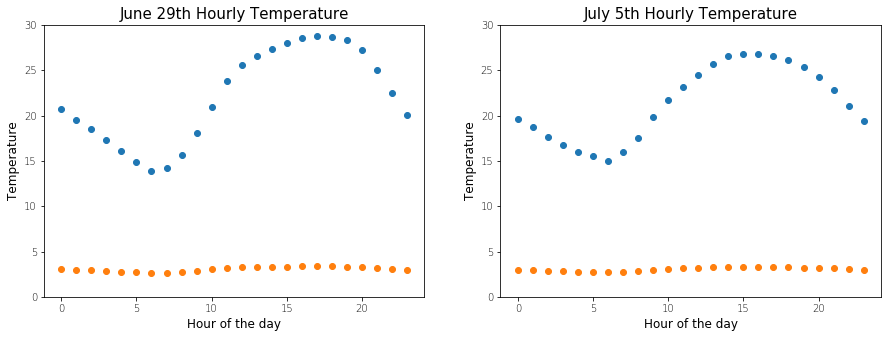

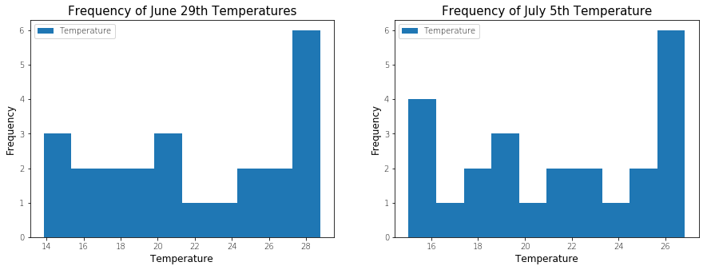

```python
fig1, (ax1,ax2) = plt.subplots(1, 2, figsize=(15,5))
fig2, (ax3,ax4) = plt.subplots(1, 2, figsize=(15,5))

"""
The one liner above can be split into 3 steps:
fig = plt.figure(figsize=(15,5)) # create a figure object
ax1 = fig.add_subplot(1, 2, 1) # create an axes object in the figure, 1 row, 2 columns wide, id:1
ax2 = fig.add_subplot(1, 2, 2) # create an axes object in the figure, 1 row, 2 columns wide, id:2
"""
#ax2.set_xticks([5])
#ax1.set_xticks([0,12,24])
ax1.plot(df_June, 'o') #.apply(np.log)
ax2.plot(df_July, 'o')

ax1.set_xlabel('Hour of the day', fontsize=12)
ax1.set_ylabel('Temperature', fontsize=12)
ax2.set_xlabel('Hour of the day', fontsize=12)
ax2.set_ylabel('Temperature', fontsize=12)

ax1.set_title('June 29th Hourly Temperature', fontsize=15)
ax2.set_title('July 5th Hourly Temperature', fontsize=15)

ax1.set_ylim(0, 30);
ax2.set_ylim(0, 30);

ax1.plot(df_June.apply(np.log), 'o')
ax2.plot(df_July.apply(np.log), 'o')


df_June.plot.hist(ax=ax3);
df_July.plot.hist(ax=ax4);

ax3.set_xlabel('Temperature', fontsize=12)
ax3.set_ylabel('Frequency', fontsize=12)
ax4.set_xlabel('Temperature', fontsize=12)
ax4.set_ylabel('Frequency', fontsize=12)

ax3.set_title('Frequency of June 29th Temperatures', fontsize=15)
ax4.set_title('Frequency of July 5th Temperature', fontsize=15)
```

Comparing these figures side by side can lead to erroneous interpretations because, altough the shapes look identical, the scales on the axis are different. Let's plot them in the same figure to get a better sense of our data

```python
# thank you unsym on stack overflow https://stackoverflow.com/questions/16716302/how-do-i-fit-a-sine-curve-to-my-data-with-pylab-and-numpy/42322656

import numpy, scipy.optimize

def fit_sin(tt, yy):
    '''Fit sin to the input time sequence, and return fitting parameters
    "amp", "omega", "phase", "offset", "freq", "period" and "fitfunc"'''
    tt = numpy.array(tt)
    yy = numpy.array(yy)
    ff = numpy.fft.fftfreq(len(tt), (tt[1]-tt[0]))   # assume uniform spacing
    Fyy = abs(numpy.fft.fft(yy))
    guess_freq = abs(ff[numpy.argmax(Fyy[1:])+1])   # excluding the zero frequency "peak", which is related to offset
    guess_amp = numpy.std(yy) * 2.**0.5
    guess_offset = numpy.mean(yy)
    guess = numpy.array([guess_amp, 2.*numpy.pi*guess_freq, 0., guess_offset])

    def sinfunc(t, A, w, p, c):  return A * numpy.sin(w*t + p) + c
    popt, pcov = scipy.optimize.curve_fit(sinfunc, tt, yy, p0=guess)
    A, w, p, c = popt
    f = w/(2.*numpy.pi)
    fitfunc = lambda t: A * numpy.sin(w*t + p) + c
    return {"amp": A, "omega": w, "phase": p, "offset": c, "freq": f, "period": 1./f,
            "fitfunc": fitfunc, "maxcov": numpy.max(pcov), "rawres": (guess,popt,pcov)}
```

```
Amplitude=1.0478773957010232, Angular freq.=2.003848098703852, phase=0.5006598783759361, offset=3.9875898995591994, Max. Cov.=0.012004357223659154
```

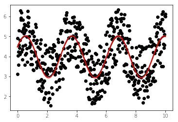

```python
N, amp, omega, phase, offset, noise = 500, 1., 2., .5, 4., 3
#N, amp, omega, phase, offset, noise = 50, 1., .4, .5, 4., .2
#N, amp, omega, phase, offset, noise = 200, 1., 20, .5, 4., 1
tt = np.linspace(0, 10, N)           # 500 numbers equally spaced between 0 and 10
tt2 = np.linspace(0, 10, 10*N)       # 5000 numbers equally spaced between 0 and 10
yy = amp*np.sin(omega*tt + phase) + offset
yynoise = yy + noise*(np.random.random(len(tt))-0.5)
#print(yynoise)

res = fit_sin(tt, yynoise)
print( "Amplitude=%(amp)s, Angular freq.=%(omega)s, phase=%(phase)s, offset=%(offset)s, Max. Cov.=%(maxcov)s" % res )

plt_lab.plot(tt, yy, "-k", label="y", linewidth=2)
plt_lab.plot(tt, yynoise, "ok", label="y with noise")
plt_lab.plot(tt2, res["fitfunc"](tt2), "r-", label="y fit curve", linewidth=2)
#plt.legend(loc="best")
plt_lab.show()
```